# Are Wins a Quarterback Stat?

Brian Papiernik, Casey Kmet, Kiki Van Zanten, JD Bertrand, Quinn Murphy

2023-12-10

```r
library(nflfastR) # Load nflfastR
library(tidyverse) # load tidyverse
library(reldist) # Load reldist for gini
```

```r
library(ggplot2) # Load ggplot2
library(ggimage) # Load ggimage
library(ggdark) # Load ggdark
library(ggrepel) # Load ggrepel
library(dplyr)



# install.packages("randomForest")
# install.packages("rpart")
# install.packages("caret")
library(randomForest) # Load randomForest package to run bagging
library(rpart) # Load rpart for decision trees
library(caret) # Used for analysing results
#install.packages("splitstackshape")
library(splitstackshape) # Used for stratified sampling
#install.packages("xgboost")
#install.packages("caret")
#install.packages("ggplot2")
#library(devtools)
#install.packages("githubinstall")
library(devtools)
#install_github("AppliedDataSciencePartners/xgboostExplainer")
#install.packages("SHAPforxgboost")
#install.packages("GGally")
#install.packages("gh")

library(xgboost) # Load XGBoost
library(caret) # Load Caret
library(ggplot2) # Load ggplot2
library(pROC) # Load proc
library(SHAPforxgboost) # Load shap for XGBoost
library(caTools)
library(dplyr)
library(GGally)
library(pROC) # Load proc
library(data.table)
library(gh)
library(commonmark)
library(xgboostExplainer)
```

# Data Preparations

The lines below are how our group ended up extracting the 2023 play by play NFL dataset from the R package and choosing the relevant variables for our analysis.

```r
pbp_2023 <- load_pbp(2023)
playerstats <- load_player_stats(2023)
```

```r
head(pbp_2023)
```

```
## ── nflverse play by play data ──────────────────────────────────────────────────
```

```
## ℹ Data updated: 2023-12-12 04:06:06 EST
```

```
## # A tibble: 6 × 372
##   play_id game_id      old_game_id home_team away_team season_type  week posteam
##     <dbl> <chr>        <chr>       <chr>     <chr>     <chr>       <int> <chr>
## 1       1 2023_01_ARI… 2023091007  WAS       ARI       REG             1 <NA>
## 2      39 2023_01_ARI… 2023091007  WAS       ARI       REG             1 WAS
## 3      55 2023_01_ARI… 2023091007  WAS       ARI       REG             1 WAS
## 4      77 2023_01_ARI… 2023091007  WAS       ARI       REG             1 WAS
## 5     102 2023_01_ARI… 2023091007  WAS       ARI       REG             1 WAS
## 6     124 2023_01_ARI… 2023091007  WAS       ARI       REG             1 WAS
## # ℹ 364 more variables: posteam_type <chr>, defteam <chr>, side_of_field <chr>,
## #   yardline_100 <dbl>, game_date <chr>, quarter_seconds_remaining <dbl>,
## #   half_seconds_remaining <dbl>, game_seconds_remaining <dbl>,
## #   game_half <chr>, quarter_end <dbl>, drive <dbl>, sp <dbl>, qtr <dbl>,
## #   down <dbl>, goal_to_go <dbl>, time <chr>, yrdln <chr>, ydstogo <dbl>,
## #   ydsnet <dbl>, desc <chr>, play_type <chr>, yards_gained <dbl>,
## #   shotgun <dbl>, no_huddle <dbl>, qb_dropback <dbl>, qb_kneel <dbl>, …
```

```r
head(playerstats)
```

```
## ── nflverse player stats: offense ──────────────────────────────────────────────
```

```
## ℹ Data updated: 2023-12-12 04:08:46 EST
```

```
## # A tibble: 6 × 53
##   player_id player_name player_display_name position position_group headshot_url
##   <chr>     <chr>       <chr>               <chr>    <chr>          <chr>
## 1 00-00234… A.Rodgers   Aaron Rodgers       QB       QB             https://sta…
## 2 00-00242… M.Lewis     Marcedes Lewis      TE       TE             https://sta…
## 3 00-00242… M.Lewis     Marcedes Lewis      TE       TE             https://sta…
## 4 00-00242… M.Lewis     Marcedes Lewis      TE       TE             https://sta…
## 5 00-00242… M.Lewis     Marcedes Lewis      TE       TE             https://sta…
## 6 00-00261… J.Flacco    Joe Flacco          QB       QB             https://sta…
## # ℹ 47 more variables: recent_team <chr>, season <int>, week <int>,
## #   season_type <chr>, completions <int>, attempts <int>, passing_yards <dbl>,
## #   passing_tds <int>, interceptions <dbl>, sacks <dbl>, sack_yards <dbl>,
## #   sack_fumbles <int>, sack_fumbles_lost <int>, passing_air_yards <dbl>,
## #   passing_yards_after_catch <dbl>, passing_first_downs <dbl>,
## #   passing_epa <dbl>, passing_2pt_conversions <int>, pacr <dbl>, dakota <dbl>,
## #   carries <int>, rushing_yards <dbl>, rushing_tds <int>, …
```

Here we continue to remove unwanted variables

```r
pbp1_2023 <- pbp_2023 %>%
  select(-c(,6,11,25,28,50:53,56:63,293:297,299,303,307,326:335,338:340,360:364))
```

After, our group creates a Time Split column that splits the string by the :. After we convert both column into numeric data and create a new column called drive_seconds that takes the minute column, multiplies it by 60 and added it to the seconds columns. This new variable gives the total amount of seconds for each drive in a unique game_id.

```r
pbp1_2023$TimeSplit <- strsplit(as.character(pbp1_2023$drive_time_of_possession), ":")

# Extract the components and append to new columns
pbp1_2023$minute <- sapply(pbp1_2023$TimeSplit, function(x) as.numeric(x[1]))
pbp1_2023$seconds <- sapply(pbp1_2023$TimeSplit, function(x) as.numeric(x[2]))



pbp1_2023$drive_seconds <- (pbp1_2023$minute *60) + pbp1_2023$seconds
pbp1_2023$drive_seconds
```

[output not shown]

[output cut: 2012 more lines]

```r
head(pbp1_2023)
```

```
## ── nflverse play by play data ──────────────────────────────────────────────────
```

```
## ℹ Data updated: 2023-12-12 04:06:06 EST
```

```
## # A tibble: 6 × 334
##   play_id game_id     old_game_id home_team away_team  week posteam posteam_type
##     <dbl> <chr>       <chr>       <chr>     <chr>     <int> <chr>   <chr>
## 1       1 2023_01_AR… 2023091007  WAS       ARI           1 <NA>    <NA>
## 2      39 2023_01_AR… 2023091007  WAS       ARI           1 WAS     home
## 3      55 2023_01_AR… 2023091007  WAS       ARI           1 WAS     home
## 4      77 2023_01_AR… 2023091007  WAS       ARI           1 WAS     home
## 5     102 2023_01_AR… 2023091007  WAS       ARI           1 WAS     home
## 6     124 2023_01_AR… 2023091007  WAS       ARI           1 WAS     home
## # ℹ 326 more variables: defteam <chr>, yardline_100 <dbl>, game_date <chr>,
## #   quarter_seconds_remaining <dbl>, half_seconds_remaining <dbl>,
## #   game_seconds_remaining <dbl>, game_half <chr>, quarter_end <dbl>,
## #   drive <dbl>, sp <dbl>, qtr <dbl>, down <dbl>, goal_to_go <dbl>, time <chr>,
## #   ydstogo <dbl>, ydsnet <dbl>, play_type <chr>, yards_gained <dbl>,
## #   shotgun <dbl>, no_huddle <dbl>, qb_dropback <dbl>, qb_kneel <dbl>,
## #   qb_spike <dbl>, qb_scramble <dbl>, pass_length <chr>, …
```

```r
selected_row <- pbp_2023$play_type_nfl[175]
```

Here, we continue to remove unwanted variables.

```r
pbp2_2023 <- pbp1_2023 %>%
  select(-c(,1,3,8:9,11,22,45,69:78,82:83,86,87:91,96:103,156,159,162,165,168,170:223,225:254,255,257,259,261:262,268:270,275, 276:277,280:281,283,285,289:290,292:299,302:310,314:322,331:333))
```

```r
head(pbp2_2023)
```

```
## ── nflverse play by play data ──────────────────────────────────────────────────
```

```
## ℹ Data updated: 2023-12-12 04:06:06 EST
```

```
## # A tibble: 6 × 166
##   game_id  home_team away_team  week posteam yardline_100 quarter_seconds_rema…¹
##   <chr>    <chr>     <chr>     <int> <chr>          <dbl>                  <dbl>
## 1 2023_01… WAS       ARI           1 <NA>              NA                    900
## 2 2023_01… WAS       ARI           1 WAS               35                    900
## 3 2023_01… WAS       ARI           1 WAS               75                    900
## 4 2023_01… WAS       ARI           1 WAS               72                    870
## 5 2023_01… WAS       ARI           1 WAS               66                    835
## 6 2023_01… WAS       ARI           1 WAS               64                    796
## # ℹ abbreviated name: ¹quarter_seconds_remaining
## # ℹ 159 more variables: half_seconds_remaining <dbl>,
## #   game_seconds_remaining <dbl>, game_half <chr>, quarter_end <dbl>,
## #   drive <dbl>, sp <dbl>, qtr <dbl>, down <dbl>, goal_to_go <dbl>,
## #   ydstogo <dbl>, ydsnet <dbl>, play_type <chr>, yards_gained <dbl>,
## #   shotgun <dbl>, no_huddle <dbl>, qb_dropback <dbl>, qb_kneel <dbl>,
## #   qb_spike <dbl>, qb_scramble <dbl>, pass_length <chr>, …
```

After, we create a new dataset by removing more of the unwanted variables from the previous dataset.

```r
pbp3_2023 <- pbp2_2023 %>%
  select(-c(,7:8,10:11,14))
head(pbp3_2023)
```

```
## ── nflverse play by play data ──────────────────────────────────────────────────
```

```
## ℹ Data updated: 2023-12-12 04:06:06 EST
```

```
## # A tibble: 6 × 161
##   game_id  home_team away_team  week posteam yardline_100 game_seconds_remaining
##   <chr>    <chr>     <chr>     <int> <chr>          <dbl>                  <dbl>
## 1 2023_01… WAS       ARI           1 <NA>              NA                   3600
## 2 2023_01… WAS       ARI           1 WAS               35                   3600
## 3 2023_01… WAS       ARI           1 WAS               75                   3600
## 4 2023_01… WAS       ARI           1 WAS               72                   3570
## 5 2023_01… WAS       ARI           1 WAS               66                   3535
## 6 2023_01… WAS       ARI           1 WAS               64                   3496
## # ℹ 154 more variables: drive <dbl>, sp <dbl>, down <dbl>, goal_to_go <dbl>,
## #   ydstogo <dbl>, ydsnet <dbl>, play_type <chr>, yards_gained <dbl>,
## #   shotgun <dbl>, no_huddle <dbl>, qb_dropback <dbl>, qb_kneel <dbl>,
## #   qb_spike <dbl>, qb_scramble <dbl>, pass_length <chr>, pass_location <chr>,
## #   air_yards <dbl>, yards_after_catch <dbl>, run_location <chr>,
## #   run_gap <chr>, field_goal_result <chr>, kick_distance <dbl>,
## #   extra_point_result <chr>, two_point_conv_result <chr>, …
```

Again, we finally remove more unwanted variables.

```r
pbp4_2023 <- pbp3_2023 %>%
  select(-c(,11,78,95:96,114,134:135)) %>%
  filter(home_score > away_score)
pbp4_2023
```

```
## ── nflverse play by play data ──────────────────────────────────────────────────
```

```
## ℹ Data updated: 2023-12-12 04:06:06 EST
```

```
## # A tibble: 20,018 × 154
##    game_id home_team away_team  week posteam yardline_100 game_seconds_remaining
##    <chr>   <chr>     <chr>     <int> <chr>          <dbl>                  <dbl>
##  1 2023_0… WAS       ARI           1 <NA>              NA                   3600
##  2 2023_0… WAS       ARI           1 WAS               35                   3600
##  3 2023_0… WAS       ARI           1 WAS               75                   3600
##  4 2023_0… WAS       ARI           1 WAS               72                   3570
##  5 2023_0… WAS       ARI           1 WAS               66                   3535
##  6 2023_0… WAS       ARI           1 WAS               64                   3496
##  7 2023_0… WAS       ARI           1 WAS               64                   3492
##  8 2023_0… WAS       ARI           1 WAS               52                   3454
##  9 2023_0… WAS       ARI           1 WAS               51                   3416
## 10 2023_0… WAS       ARI           1 WAS               51                   3411
## # ℹ 20,008 more rows
## # ℹ 147 more variables: drive <dbl>, sp <dbl>, down <dbl>, ydstogo <dbl>,
## #   ydsnet <dbl>, play_type <chr>, yards_gained <dbl>, shotgun <dbl>,
## #   no_huddle <dbl>, qb_dropback <dbl>, qb_kneel <dbl>, qb_spike <dbl>,
## #   qb_scramble <dbl>, pass_length <chr>, pass_location <chr>, air_yards <dbl>,
## #   yards_after_catch <dbl>, run_location <chr>, run_gap <chr>,
## #   field_goal_result <chr>, kick_distance <dbl>, extra_point_result <chr>, …
```

```r
pbp4_2023$win <- ifelse(pbp4_2023$home_score > pbp4_2023$away_score & pbp4_2023$home_team == pbp4_2023$posteam, 1, 0)
pbp4_2023
```

```
## ── nflverse play by play data ──────────────────────────────────────────────────
```

```
## ℹ Data updated: 2023-12-12 04:06:06 EST
```

```
## # A tibble: 20,018 × 155
##    game_id home_team away_team  week posteam yardline_100 game_seconds_remaining
##    <chr>   <chr>     <chr>     <int> <chr>          <dbl>                  <dbl>
##  1 2023_0… WAS       ARI           1 <NA>              NA                   3600
##  2 2023_0… WAS       ARI           1 WAS               35                   3600
##  3 2023_0… WAS       ARI           1 WAS               75                   3600
##  4 2023_0… WAS       ARI           1 WAS               72                   3570
##  5 2023_0… WAS       ARI           1 WAS               66                   3535
##  6 2023_0… WAS       ARI           1 WAS               64                   3496
##  7 2023_0… WAS       ARI           1 WAS               64                   3492
##  8 2023_0… WAS       ARI           1 WAS               52                   3454
##  9 2023_0… WAS       ARI           1 WAS               51                   3416
## 10 2023_0… WAS       ARI           1 WAS               51                   3411
## # ℹ 20,008 more rows
## # ℹ 148 more variables: drive <dbl>, sp <dbl>, down <dbl>, ydstogo <dbl>,
## #   ydsnet <dbl>, play_type <chr>, yards_gained <dbl>, shotgun <dbl>,
## #   no_huddle <dbl>, qb_dropback <dbl>, qb_kneel <dbl>, qb_spike <dbl>,
## #   qb_scramble <dbl>, pass_length <chr>, pass_location <chr>, air_yards <dbl>,
## #   yards_after_catch <dbl>, run_location <chr>, run_gap <chr>,
## #   field_goal_result <chr>, kick_distance <dbl>, extra_point_result <chr>, …
```

pbp4_2023$actual_yac_over_xyac = actual yards after catch minus expected yards after catch was create to see how well receivers overperform the mean of the expected yard after catch based on ball location. better receivers should have a higher value

xyac_mean_yardage is Average expected yards after the catch based on where the ball was caught.

```r
pbp4_2023$passing_yards[is.na(pbp4_2023$passing_yards)] <- 0
pbp4_2023$rushing_yards[is.na(pbp4_2023$rushing_yards)] <- 0
pbp4_2023$receiving_yards[is.na(pbp4_2023$receiving_yards)] <- 0
pbp4_2023$air_yards[is.na(pbp4_2023$air_yards)] <- 0
pbp4_2023$actual_yac_over_xyac = pbp4_2023$yards_after_catch - pbp4_2023$xyac_mean_yardage
head(pbp4_2023)
```

```
## ── nflverse play by play data ──────────────────────────────────────────────────
```

```
## ℹ Data updated: 2023-12-12 04:06:06 EST
```

```
## # A tibble: 6 × 156
##   game_id  home_team away_team  week posteam yardline_100 game_seconds_remaining
##   <chr>    <chr>     <chr>     <int> <chr>          <dbl>                  <dbl>
## 1 2023_01… WAS       ARI           1 <NA>              NA                   3600
## 2 2023_01… WAS       ARI           1 WAS               35                   3600
## 3 2023_01… WAS       ARI           1 WAS               75                   3600
## 4 2023_01… WAS       ARI           1 WAS               72                   3570
## 5 2023_01… WAS       ARI           1 WAS               66                   3535
## 6 2023_01… WAS       ARI           1 WAS               64                   3496
## # ℹ 149 more variables: drive <dbl>, sp <dbl>, down <dbl>, ydstogo <dbl>,
## #   ydsnet <dbl>, play_type <chr>, yards_gained <dbl>, shotgun <dbl>,
## #   no_huddle <dbl>, qb_dropback <dbl>, qb_kneel <dbl>, qb_spike <dbl>,
## #   qb_scramble <dbl>, pass_length <chr>, pass_location <chr>, air_yards <dbl>,
## #   yards_after_catch <dbl>, run_location <chr>, run_gap <chr>,
## #   field_goal_result <chr>, kick_distance <dbl>, extra_point_result <chr>,
## #   two_point_conv_result <chr>, home_timeouts_remaining <dbl>, …
```

Disregard pbp5_2023

```r
pbp5_2023 <- pbp4_2023 %>%
  group_by(game_id, passer_player_id, ) %>%
  mutate(total_passing_yards = sum(passing_yards),
         total_rushing_yards = sum(rushing_yards),
         actual_yac_over_xyac = yards_after_catch - xyac_mean_yardage)

pbp5_2023
```

```
## # A tibble: 20,018 × 158
## # Groups:   game_id, passer_player_id [405]
##    game_id home_team away_team  week posteam yardline_100 game_seconds_remaining
##    <chr>   <chr>     <chr>     <int> <chr>          <dbl>                  <dbl>
##  1 2023_0… WAS       ARI           1 <NA>              NA                   3600
##  2 2023_0… WAS       ARI           1 WAS               35                   3600
##  3 2023_0… WAS       ARI           1 WAS               75                   3600
##  4 2023_0… WAS       ARI           1 WAS               72                   3570
##  5 2023_0… WAS       ARI           1 WAS               66                   3535
##  6 2023_0… WAS       ARI           1 WAS               64                   3496
##  7 2023_0… WAS       ARI           1 WAS               64                   3492
##  8 2023_0… WAS       ARI           1 WAS               52                   3454
##  9 2023_0… WAS       ARI           1 WAS               51                   3416
## 10 2023_0… WAS       ARI           1 WAS               51                   3411
## # ℹ 20,008 more rows
## # ℹ 151 more variables: drive <dbl>, sp <dbl>, down <dbl>, ydstogo <dbl>,
## #   ydsnet <dbl>, play_type <chr>, yards_gained <dbl>, shotgun <dbl>,
## #   no_huddle <dbl>, qb_dropback <dbl>, qb_kneel <dbl>, qb_spike <dbl>,
## #   qb_scramble <dbl>, pass_length <chr>, pass_location <chr>, air_yards <dbl>,
## #   yards_after_catch <dbl>, run_location <chr>, run_gap <chr>,
## #   field_goal_result <chr>, kick_distance <dbl>, extra_point_result <chr>, …
```

Here we create our most important dataset. This code snippet is written in R and uses the dplyr package for data manipulation. It takes a dataset (pbp4_2023) and transforms it into pbp6_2023 by grouping data by multiple variables including game ID, win status, team, and player IDs for passers, rushers, and receivers. It calculates various aggregated statistics such as total and average passing, rushing, and receiving yards, completion percentages, touchdown counts, and other metrics like average Expected Points Added (EPA) for quarterbacks, average yards after catch EPA, and total penalty yards. The data is also summarized for play types like shotgun or no-huddle plays. The resulting dataset pbp6_2023 provides a comprehensive statistical breakdown for each game, team, and key players, focusing on different aspects of play-by-play performance.

A summary of each derivative statistical variable based on play by play performance metrics is provided below. The derivative statistical data for each position are divided into run plays and pass plays and are broken down into pass length and pass location for pass plays or run gap and run location for run plays. These derivative statistical data are further grouped for each specific quarterback_id, rusher_id, and wide_receiver_id for each specific game_id based on the zone locations above:

“broken down by pass length and pass location for quarterback_id and wide receiver id for each specific game_id” total passing yards pass attempts incomplete pass completion percentage average passing yards total air passing yards - total yards thrown with or without completion average air passing yards - average yards thrown with or without completion passing touchdown totals total receiving yards average receiving yards average cpoe - completion percentage above expectation “CPOE accounts for air distance, distance from the sideline, target separation from the nearest defender, the quarterback’s distance from the closest pass rusher, pass speed, and time to throw.” total first downs average quarterback expected points added (epa) average expected yards after catch epa average air yards epa average yards after catch epa actual yards after catch minus expected points after catch epa (self-created stat to show how well a receiver performs in yards after catch compared to mean expected yards after catch) total_actual_yac_over_xyac = sum(actual_yac_over_xyac) avg_actual_yac_over_xyac = mean(actual_yac_over_xyac) interceptions fumble lost fumble forced

“broken down by run zone and run location for rusher_id for each specific game_id” can be a performance metric for oline and running backs

total rushing yards average rushing yards rush attempt rush touchdowns first down rush total first downs fumble lost fumble forced

total penalty yards total time of possession average time of possession

Play type: shotgun no huddle quarterback dropback quarterback scramble

Play type result: third down conversion third down fail fourth down conversion fourth down fail

```r
pbp6_2023 <- pbp4_2023 %>%
  group_by(game_id, win, posteam, passer_player_id, rusher_player_id, receiver_player_id, pass_length, pass_location, run_gap, run_location, penalty_player_id) %>%
  summarise(total_passing_yards = sum(passing_yards),
            pass_attempts = sum(pass_attempt),
            incomplete_pass = sum(incomplete_pass),
            completion_per = 1 - (incomplete_pass/pass_attempts),
            avg_passing_yards = mean(passing_yards),
            total_air_passing_yards = sum(air_yards),
            avg_air_passing_yards = mean(air_yards),
            pass_touchdown = sum(pass_touchdown),
            total_rushing_yards = sum(rushing_yards),
            avg_rushing_yards = mean(rushing_yards),
            rush_attempt = sum(rush_attempt),
            rush_touchdown = sum(rush_touchdown),
            total_receiving_yards = sum(receiving_yards),
            avg_receiving_yards = mean(receiving_yards),
            avg_cpoe = mean(cpoe),
            avg_qb_epa = mean(qb_epa),
            avg_xyac_epa = mean(xyac_epa),
            avg_time_of_possession = mean(drive_seconds),
            total_time_of_possession = sum(drive_seconds),
            avg_air_epa = mean(air_epa),
            avg_yac_epa = mean(yac_epa),
            actual_yac_over_xyac_epa = avg_yac_epa - avg_xyac_epa,
            total_actual_yac_over_xyac = sum(actual_yac_over_xyac),
            avg_actual_yac_over_xyac = mean(actual_yac_over_xyac),
            total_penalty_yards = sum(penalty_yards),
            total_first_downs = sum(first_down),
            interception = sum(interception),
            fumble_lost = sum(fumble_lost),
            fumble_forced = sum(fumble_forced),
            third_down_converted = sum(third_down_converted),
            third_down_failed = sum(third_down_failed),
            fourth_down_converted = sum(fourth_down_converted),
            fourth_down_failed = sum(fourth_down_failed),
            shotgun = sum(shotgun),
            no_huddle = sum(no_huddle),
            qb_dropback = sum(qb_dropback),
            qb_scramble = sum(qb_scramble),
            first_down_rush = sum(first_down_rush),
            first_down_pass = sum(first_down_pass),

            .groups = 'drop')
pbp6_2023
```

```
## # A tibble: 9,371 × 50
##    game_id      win posteam passer_player_id rusher_player_id receiver_player_id
##    <chr>      <dbl> <chr>   <chr>            <chr>            <chr>
##  1 2023_01_A…     0 ARI     00-0033949       <NA>             00-0030061
##  2 2023_01_A…     0 ARI     00-0033949       <NA>             00-0030061
##  3 2023_01_A…     0 ARI     00-0033949       <NA>             00-0030061
##  4 2023_01_A…     0 ARI     00-0033949       <NA>             00-0033251
##  5 2023_01_A…     0 ARI     00-0033949       <NA>             00-0033553
##  6 2023_01_A…     0 ARI     00-0033949       <NA>             00-0033553
##  7 2023_01_A…     0 ARI     00-0033949       <NA>             00-0033553
##  8 2023_01_A…     0 ARI     00-0033949       <NA>             00-0035662
##  9 2023_01_A…     0 ARI     00-0033949       <NA>             00-0035662
## 10 2023_01_A…     0 ARI     00-0033949       <NA>             00-0036936
## # ℹ 9,361 more rows
## # ℹ 44 more variables: pass_length <chr>, pass_location <chr>, run_gap <chr>,
## #   run_location <chr>, penalty_player_id <chr>, total_passing_yards <dbl>,
## #   pass_attempts <dbl>, incomplete_pass <dbl>, completion_per <dbl>,
## #   avg_passing_yards <dbl>, total_air_passing_yards <dbl>,
## #   avg_air_passing_yards <dbl>, pass_touchdown <dbl>,
## #   total_rushing_yards <dbl>, avg_rushing_yards <dbl>, rush_attempt <dbl>, …
```

In the code below, we replace all the na values with either the mean or a value of 0 depending on the column

```r
pbp7_2023 <- pbp6_2023 %>%
  select(-c(1, 3:6, 11)) %>%
  mutate_all(~replace(., is.na(.), mean(., na.rm = TRUE)))
pbp7_2023 <- pbp7_2023 %>%
  mutate_at(vars(2:5), ~replace(., is.na(.), 0))
```

In the code below, our group creates two new datasets: training set and testing set. The training set nfl_train has 7496 observations along with the values for 44 different variables. The testing set nfl_test has 1875 observations along with the values for 44 different variables.

```r
set.seed(11111)
sample <- sample.split(pbp7_2023$win, SplitRatio = 0.8)

nfl_train <- subset(pbp7_2023, sample == TRUE)
nfl_test <- subset(pbp7_2023, sample == FALSE)

dim(nfl_train)
```

```
## [1] 7496   44
```

```r
dim(nfl_test)
```

```
## [1] 1875   44
```

The code below checks the summary statistics for each of the 44 variables in the nfl_train dataset

```r
summary(nfl_train)
```

```
##       win         pass_length        pass_location        run_gap
##  Min.   :0.0000   Length:7496        Length:7496        Length:7496
##  1st Qu.:0.0000   Class :character   Class :character   Class :character
##  Median :0.4973   Mode  :character   Mode  :character   Mode  :character
##  Mean   :0.4973
##  3rd Qu.:1.0000
##  Max.   :1.0000
##  run_location       total_passing_yards pass_attempts   incomplete_pass
##  Length:7496        Min.   :-11.00      Min.   :0.000   Min.   :0.0000
##  Class :character   1st Qu.:  0.00      1st Qu.:0.000   1st Qu.:0.0000
##  Mode  :character   Median :  0.00      Median :1.000   Median :0.0000
##                     Mean   :  5.92      Mean   :0.931   Mean   :0.2866
##                     3rd Qu.:  7.00      3rd Qu.:1.000   3rd Qu.:0.2876
##                     Max.   :122.00      Max.   :9.000   Max.   :5.0000
##  completion_per   avg_passing_yards total_air_passing_yards
##  Min.   :0.0000   Min.   :-11.000   Min.   :-18.000
##  1st Qu.:0.6610   1st Qu.:  0.000   1st Qu.:  0.000
##  Median :0.6610   Median :  0.000   Median :  0.000
##  Mean   :0.6628   Mean   :  3.707   Mean   :  6.537
##  3rd Qu.:1.0000   3rd Qu.:  5.000   3rd Qu.:  9.000
##  Max.   :1.0000   Max.   : 81.000   Max.   :142.000
##  avg_air_passing_yards pass_touchdown    total_rushing_yards avg_rushing_yards
##  Min.   :-12.000       Min.   :0.00000   Min.   :-11.00      Min.   :-11.000
##  1st Qu.:  0.000       1st Qu.:0.00000   1st Qu.:  0.00      1st Qu.:  0.000
##  Median :  0.000       Median :0.00000   Median :  0.00      Median :  0.000
##  Mean   :  4.448       Mean   :0.03561   Mean   :  2.74      Mean   :  1.368
##  3rd Qu.:  6.000       3rd Qu.:0.00000   3rd Qu.:  2.00      3rd Qu.:  1.000
##  Max.   : 65.000       Max.   :2.00000   Max.   :126.00      Max.   : 69.000
##   rush_attempt     rush_touchdown    total_receiving_yards avg_receiving_yards
##  Min.   : 0.0000   Min.   :0.00000   Min.   :-11.000       Min.   :-11.000
##  1st Qu.: 0.0000   1st Qu.:0.00000   1st Qu.:  0.000       1st Qu.:  0.000
##  Median : 0.0000   Median :0.00000   Median :  0.000       Median :  0.000
##  Mean   : 0.6817   Mean   :0.02102   Mean   :  5.918       Mean   :  3.705
##  3rd Qu.: 1.0000   3rd Qu.:0.00000   3rd Qu.:  7.000       3rd Qu.:  5.000
##  Max.   :18.0000   Max.   :2.00000   Max.   :122.000       Max.   : 81.000
##     avg_cpoe          avg_qb_epa        avg_xyac_epa     avg_time_of_possession
##  Min.   :-90.1305   Min.   :-8.97695   Min.   :0.01988   Min.   :  2.0
##  1st Qu.: -0.4336   1st Qu.:-0.61238   1st Qu.:0.72857   1st Qu.:134.0
##  Median : -0.4336   Median :-0.08961   Median :0.74881   Median :207.2
##  Mean   : -0.1846   Mean   : 0.01075   Mean   :0.74662   Mean   :215.6
```

[output cut: 29 more lines]

```
##  Max.   :2.00000   Max.   :3.0000       Max.   :5.0000    Max.   :2.00000
##  fourth_down_failed    shotgun         no_huddle       qb_dropback
##  Min.   :0.00000    Min.   : 0.000   Min.   :0.0000   Min.   :0.0000
##  1st Qu.:0.00000    1st Qu.: 1.000   1st Qu.:0.0000   1st Qu.:0.0000
##  Median :0.00000    Median : 1.000   Median :0.0000   Median :1.0000
##  Mean   :0.01851    Mean   : 1.184   Mean   :0.1451   Mean   :0.9726
##  3rd Qu.:0.00000    3rd Qu.: 2.000   3rd Qu.:0.0000   3rd Qu.:1.0000
##  Max.   :2.00000    Max.   :17.000   Max.   :4.0000   Max.   :9.0000
##   qb_scramble      first_down_rush  first_down_pass
##  Min.   :0.00000   Min.   :0.0000   Min.   :0.0000
##  1st Qu.:0.00000   1st Qu.:0.0000   1st Qu.:0.0000
##  Median :0.00000   Median :0.0000   Median :0.0000
##  Mean   :0.04816   Mean   :0.1601   Mean   :0.2850
##  3rd Qu.:0.00000   3rd Qu.:0.0000   3rd Qu.:0.2788
##  Max.   :5.00000   Max.   :5.0000   Max.   :5.0000
```

```r
sapply(lapply(nfl_train, unique),length)
```

```
##                        win                pass_length
##                          3                          3
##              pass_location                    run_gap
##                          4                          4
##               run_location        total_passing_yards
##                          4                         91
##              pass_attempts            incomplete_pass
##                         11                          7
##             completion_per          avg_passing_yards
##                         22                        228
##    total_air_passing_yards      avg_air_passing_yards
##                        111                        248
##             pass_touchdown        total_rushing_yards
##                          4                         78
##          avg_rushing_yards               rush_attempt
##                        206                         15
##             rush_touchdown      total_receiving_yards
##                          4                         91
##        avg_receiving_yards                   avg_cpoe
##                        228                       3532
##                 avg_qb_epa               avg_xyac_epa
##                       7222                       3219
##     avg_time_of_possession   total_time_of_possession
##                       1511                       1373
##                avg_air_epa                avg_yac_epa
##                       3777                       3423
##   actual_yac_over_xyac_epa total_actual_yac_over_xyac
##                       3220                       1879
##   avg_actual_yac_over_xyac        total_penalty_yards
##                       1879                         40
##          total_first_downs               interception
##                          7                          4
##                fumble_lost              fumble_forced
##                          3                          4
##       third_down_converted          third_down_failed
##                          5                          7
##      fourth_down_converted         fourth_down_failed
##                          4                          4
##                    shotgun                  no_huddle
##                         11                          5
##                qb_dropback                qb_scramble
##                         11                          6
##            first_down_rush            first_down_pass
##                          7                          7
```

# Logistic Regression

In the logistic regression output below, it was interesting to see that run gap and run location were less statistically significant than pass length and pass location which can be used to say that potentially passes are more important to home wins than runs. However, to counteract that interpretation, it is interesting to see that average time of possession is statistically significant because running the ball tends to chew away the clock based on the fact that time doesn’t run on incompletions. It was interesting to see play type results like fourth down failed or play type like shotgun become statistically significant. Also, it is important to note that 2 quarterback performance metrics and 2 runningback performance metrics and 1 receiving performance metric were statistically significant. This can mean that QB performance metrics don’t always result in predicting the probability of a home win.

```r
nfl_regression_train <- nfl_train
nfl_regression_test <- nfl_test


NFLfit1 <- glm(win ~ ., data = nfl_regression_test, family = binomial(link = "logit"))
summary(NFLfit1)
```

```
##
## Call:
## glm(formula = win ~ ., family = binomial(link = "logit"), data = nfl_regression_test)
##
## Coefficients: (4 not defined because of singularities)
##                              Estimate Std. Error z value Pr(>|z|)
## (Intercept)                -0.1764933  0.4781824  -0.369 0.712059
## pass_lengthdeep            -0.6561648  0.4355080  -1.507 0.131896
## pass_lengthshort           -0.2542345  0.2690502  -0.945 0.344693
## pass_locationleft          -0.2291482  0.1557899  -1.471 0.141324
## pass_locationmiddle        -0.5039289  0.1952698  -2.581 0.009861 **
## pass_locationright                 NA         NA      NA       NA
## run_gapend                 -0.3950798  0.2738397  -1.443 0.149093
## run_gapguard               -0.4334527  0.2856168  -1.518 0.129115
## run_gaptackle              -0.4350808  0.2888402  -1.506 0.131989
## run_locationleft            0.1204207  0.1866445   0.645 0.518806
## run_locationmiddle         -0.3433044  0.2969896  -1.156 0.247703
## run_locationright                  NA         NA      NA       NA
## total_passing_yards         0.0199219  0.0200462   0.994 0.320320
## pass_attempts               0.4885743  0.6226356   0.785 0.432637
## incomplete_pass             0.3575117  0.2971120   1.203 0.228864
## completion_per             -0.3778327  0.5396757  -0.700 0.483858
## avg_passing_yards           0.0291210  0.0310233   0.939 0.347894
## total_air_passing_yards    -0.0225693  0.0118502  -1.905 0.056840 .
## avg_air_passing_yards       0.0310798  0.0235230   1.321 0.186417
## pass_touchdown              0.8718999  0.3727046   2.339 0.019315 *
## total_rushing_yards        -0.0158704  0.0188076  -0.844 0.398765
## avg_rushing_yards           0.0432733  0.0321674   1.345 0.178544
## rush_attempt                0.3110171  0.1067439   2.914 0.003572 **
## rush_touchdown              0.9082910  0.3967352   2.289 0.022055 *
## total_receiving_yards              NA         NA      NA       NA
## avg_receiving_yards                NA         NA      NA       NA
## avg_cpoe                    0.0062042  0.0043785   1.417 0.156494
## avg_qb_epa                 -0.1985589  0.0973800  -2.039 0.041449 *
## avg_xyac_epa                0.2795883  0.1969916   1.419 0.155814
## avg_time_of_possession      0.0014289  0.0005037   2.837 0.004552 **
## total_time_of_possession   -0.0001674  0.0001472  -1.137 0.255404
## avg_air_epa                -0.1366910  0.1898397  -0.720 0.471504
## avg_yac_epa                -0.0939707  0.1607034  -0.585 0.558719
## actual_yac_over_xyac_epa    0.0752695  0.1059436   0.710 0.477414
```

[output cut: 12 more lines]

```
## no_huddle                  -0.0257784  0.1386555  -0.186 0.852510
## qb_dropback                -0.5022764  0.6000080  -0.837 0.402527
## qb_scramble                 0.2836018  0.5924018   0.479 0.632129
## first_down_rush            -0.0753514  0.3343165  -0.225 0.821676
## first_down_pass             0.1555325  0.3387230   0.459 0.646110
## ---
## Signif. codes:  0 '***' 0.001 '**' 0.01 '*' 0.05 '.' 0.1 ' ' 1
##
## (Dispersion parameter for binomial family taken to be 1)
##
##     Null deviance: 2567.4  on 1874  degrees of freedom
## Residual deviance: 2441.9  on 1828  degrees of freedom
## AIC: 2575.4
##
## Number of Fisher Scoring iterations: 4
```

```r
head(nfl_train)
```

```
## # A tibble: 6 × 44
##     win pass_length pass_location run_gap run_location total_passing_yards
##   <dbl> <chr>       <chr>         <chr>   <chr>                      <dbl>
## 1     0 short       left          0       0                              0
## 2     0 short       right         0       0                              6
## 3     0 short       right         0       0                             10
## 4     0 short       left          0       0                             11
## 5     0 short       right         0       0                             17
## 6     0 short       left          0       0                              1
## # ℹ 38 more variables: pass_attempts <dbl>, incomplete_pass <dbl>,
## #   completion_per <dbl>, avg_passing_yards <dbl>,
## #   total_air_passing_yards <dbl>, avg_air_passing_yards <dbl>,
## #   pass_touchdown <dbl>, total_rushing_yards <dbl>, avg_rushing_yards <dbl>,
## #   rush_attempt <dbl>, rush_touchdown <dbl>, total_receiving_yards <dbl>,
## #   avg_receiving_yards <dbl>, avg_cpoe <dbl>, avg_qb_epa <dbl>,
## #   avg_xyac_epa <dbl>, avg_time_of_possession <dbl>, …
```

# XGBoost Model

```r
dtrain <- xgb.DMatrix(data = as.matrix(nfl_train[,-c(1:5)]), label = as.numeric(nfl_train$win))
# Create test matrix



dtest <- xgb.DMatrix(data = as.matrix(nfl_test[,-c(1:5)]), label = as.numeric(nfl_test$win))
```

XGBoost uses its own data type called DMatrix that is an efficient method for storing sparse matrices (Many Zeros)

# Training our XGBoost Model

```r
set.seed(111111)
bst_1 <- xgboost(data = dtrain, # Set training data

               nrounds = 100, # Set number of rounds
               objective = "binary:logistic",
               eval_metric = "error",
               eval_metric = "auc",
               verbose = 1, # 1 - Prints out fit
                print_every_n = 20) # Prints out result every 20th iteration
set.seed(111111)
bst <- xgb.cv(data = dtrain, # Set training data

              nfold = 5, # Use 5 fold cross-validation

               eta = 0.1, # Set learning rate

               nrounds = 1000, # Set number of rounds
               early_stopping_rounds = 50,
               objective = "binary:logistic",
               eval_metric = "error",
               eval_metric = "auc",# Set number of rounds to stop at if there is no improvement

               verbose = 1, # 1 - Prints out fit
               nthread = 1, # Set number of parallel threads
               print_every_n = 20) # Prints out result every 20th iteration
```

```
## Multiple eval metrics are present. Will use test_auc for early stopping.
## Will train until test_auc hasn't improved in 50 rounds.
##
## Stopping. Best iteration:
```

From this we see 56 was the optimal number of iterations for our model. We use this number solely to ensure that we are doing a sufficient amount of rounds for our next tuning stages. We will set the number of iterations to 1000 and include an early stop parameter of 50 for our next round of tuning.

```r
max_depth_vals <- c(3, 5, 7, 10, 15) # Create vector of max depth values
min_child_weight <- c(1,3,5,7, 10, 15) # Create vector of min child values

# Expand grid of parameter values
cv_params <- expand.grid(max_depth_vals, min_child_weight)
names(cv_params) <- c("max_depth", "min_child_weight")
# Create results vector
rmse_vec  <- rep(NA, nrow(cv_params))
# Loop through results
for(i in 1:nrow(cv_params)){
  set.seed(111111)
  bst_tune <- xgb.cv(data = dtrain, # Set training data

                     nfold = 5, # Use 5 fold cross-validation

                     eta = 0.1, # Set learning rate
                     max.depth = cv_params$max_depth[i], # Set max depth
                     min_child_weight = cv_params$min_child_weight[i], # Set minimum number of samples in node to split


                     nrounds = 1000, # Set number of rounds
                     early_stopping_rounds = 50,
                     objective = "binary:logistic",
                     eval_metric = "error",
                     eval_metric = "auc",# Set number of rounds to stop at if there is no improvement

                     verbose = 1, # 1 - Prints out fit
                     nthread = 1, # Set number of parallel threads
                     print_every_n = 20 # Prints out result every 20th iteration

  ) # Set evaluation metric to use

  rmse_vec[i] <- bst_tune$evaluation_log$test_auc_mean[bst_tune$best_ntreelimit]


}
```

[output not shown]

[output cut: 94 more lines]

[output not shown]

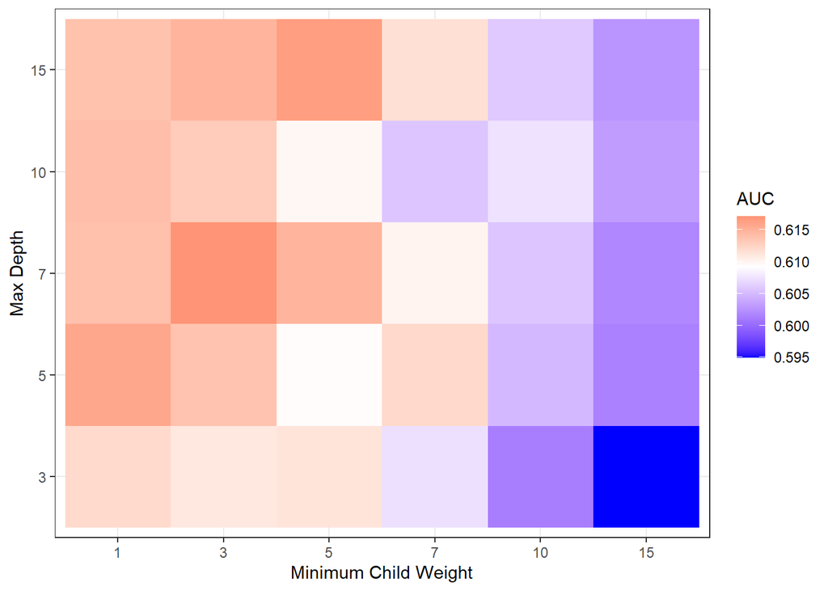

```r
# Join results in dataset
res_db <- cbind.data.frame(cv_params, rmse_vec)
names(res_db)[3] <- c("auc")
res_db$max_depth <- as.factor(res_db$max_depth) # Convert tree number to factor for plotting
res_db$min_child_weight <- as.factor(res_db$min_child_weight) # Convert node size to factor for plotting
# Print AUC heatmap
g_2 <- ggplot(res_db, aes(y = max_depth, x = min_child_weight, fill = auc)) + # set aesthetics
  geom_tile() + # Use geom_tile for heatmap
  theme_bw() + # Set theme
  scale_fill_gradient2(low = "blue", # Choose low color
                       mid = "white", # Choose mid color
                       high = "red", # Choose high color
                       midpoint =mean(res_db$auc), # Choose mid point
                       space = "Lab",
                       na.value ="grey", # Choose NA value
                       guide = "colourbar", # Set color bar
                       aesthetics = "fill") + # Select aesthetics to apply
  labs(x = "Minimum Child Weight", y = "Max Depth", fill = "AUC") # Set labels
g_2 # Generate plot
```

```r
res_db[which.max(res_db$auc),]
```

```
##   max_depth min_child_weight       auc
## 8         7                3 0.6170799
```

Here we see that the low Minimum Child Weight (3) and middle Max Depth (7) have the highest AUC and works best for our model. Our best set of results is from a max_depth value of 7 and a min child weight of 3 has the highest AUC, so our group decided to use max_depth value of 7 and a min child weight of 3.

```r
gamma_vals <- c(0, 0.05, 0.1, 0.15, 0.2) # Create vector of gamma values

# Be Careful - This can take a very long time to run
set.seed(111111)
rmse_vec  <- rep(NA, length(gamma_vals))
for(i in 1:length(gamma_vals)){
  bst_tune <- xgb.cv(data = dtrain, # Set training data

                     nfold = 5, # Use 5 fold cross-validation

                     eta = 0.1, # Set learning rate
                     max.depth = 7, # Set max depth
                     min_child_weight = 3, # Set minimum number of samples in node to split
                     gamma = gamma_vals[i], # Set minimum loss reduction for split



                     nrounds = 1000, # Set number of rounds
                     early_stopping_rounds = 50,
                     objective = "binary:logistic",
                     eval_metric = "error",
                     eval_metric = "auc",# Set number of rounds to stop at if there is no improvement

                     verbose = 1, # 1 - Prints out fit
                     nthread = 1, # Set number of parallel threads
                     print_every_n = 20 # Prints out result every 20th iteration
  ) # Set evaluation metric to use


  rmse_vec[i] <- bst_tune$evaluation_log$test_auc_mean[bst_tune$best_ntreelimit]
}
```

[output not shown]

Best is 221, now tune the subsample and colsample by tree parameters

```r
cbind.data.frame(gamma_vals, rmse_vec) #highest one because auc_vec instead of rmse_vec forgot to change name
```

```
##   gamma_vals  rmse_vec
## 1       0.00 0.6170799
## 2       0.05 0.6186093
## 3       0.10 0.6172850
## 4       0.15 0.6067115
## 5       0.20 0.6195778
```

```r
###### 3 - Subsample and Column sample Tuning ######

# Be Careful - This can take a very long time to run
subsample <- c(0.6, 0.7, 0.8, 0.9, 1) # Create vector of subsample values
colsample_by_tree <- c(0.6, 0.7, 0.8, 0.9, 1) # Create vector of col sample values

# Expand grid of tuning parameters
cv_params <- expand.grid(subsample, colsample_by_tree)
names(cv_params) <- c("subsample", "colsample_by_tree")
# Create vectors to store results
rmse_vec <- rep(NA, nrow(cv_params))
# Loop through parameter values
for(i in 1:nrow(cv_params)){
  set.seed(111111)
  bst_tune <- xgb.cv(data = dtrain, # Set training data

                     nfold = 5, # Use 5 fold cross-validation

                     eta = 0.1, # Set learning rate
                     max.depth = 7, # Set max depth
                     min_child_weight = 3, # Set minimum number of samples in node to split
                     gamma = 0.2, # Set minimum loss reduction for split
                     subsample = cv_params$subsample[i], # Set proportion of training data to use in tree
                     colsample_bytree = cv_params$colsample_by_tree[i], # Set number of variables to use in each tree

                     nrounds = 1000, # Set number of rounds
                     early_stopping_rounds = 50,
                     objective = "binary:logistic",
                     eval_metric = "error",
                     eval_metric = "auc",# Set number of rounds to stop at if there is no improvement

                     verbose = 1, # 1 - Prints out fit
                     nthread = 1, # Set number of parallel threads
                     print_every_n = 20 # Prints out result every 20th iteration
  ) # Set evaluation metric to use


  rmse_vec[i] <- bst_tune$evaluation_log$test_auc_mean[bst_tune$best_ntreelimit]


}
```

[output not shown]

[output cut: 69 more lines]

[output not shown]

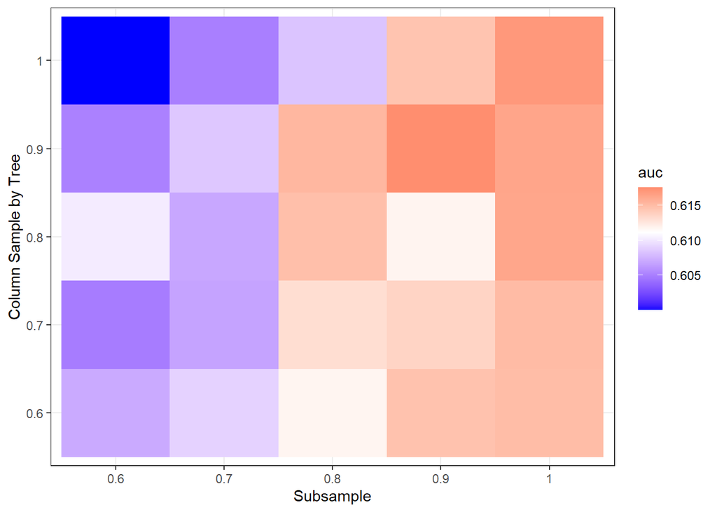

```r
res_db <- cbind.data.frame(cv_params, rmse_vec)
names(res_db)[3] <- c("auc")
res_db$subsample <- as.factor(res_db$subsample) # Convert tree number to factor for plotting
res_db$colsample_by_tree <- as.factor(res_db$colsample_by_tree) # Convert node size to factor for plotting
g_4 <- ggplot(res_db, aes(y = colsample_by_tree, x = subsample, fill = auc)) + # set aesthetics
  geom_tile() + # Use geom_tile for heatmap
  theme_bw() + # Set theme
  scale_fill_gradient2(low = "blue", # Choose low color
                       mid = "white", # Choose mid color
                       high = "red", # Choose high color
                       midpoint =mean(res_db$auc), # Choose mid point
                       space = "Lab",
                       na.value ="grey", # Choose NA value
                       guide = "colourbar", # Set color bar
                       aesthetics = "fill") + # Select aesthetics to apply
  labs(x = "Subsample", y = "Column Sample by Tree", fill = "auc") # Set labels
g_4 # Generate plot
```

```r
res_db
```

```
##    subsample colsample_by_tree       auc
## 1        0.6               0.6 0.6071296
## 2        0.7               0.6 0.6090750
## 3        0.8               0.6 0.6117864
## 4        0.9               0.6 0.6147171
## 5          1               0.6 0.6150327
## 6        0.6               0.7 0.6049160
## 7        0.7               0.7 0.6068035
## 8        0.8               0.7 0.6131256
## 9        0.9               0.7 0.6136879
## 10         1               0.7 0.6151210
## 11       0.6               0.8 0.6102487
## 12       0.7               0.8 0.6069877
## 13       0.8               0.8 0.6148797
## 14       0.9               0.8 0.6118289
## 15         1               0.8 0.6163122
## 16       0.6               0.9 0.6051614
## 17       0.7               0.9 0.6085583
## 18       0.8               0.9 0.6153296
## 19       0.9               0.9 0.6175984
## 20         1               0.9 0.6163349
## 21       0.6                 1 0.6000896
## 22       0.7                 1 0.6050338
## 23       0.8                 1 0.6083769
## 24       0.9                 1 0.6146165
## 25         1                 1 0.6170395
```

From this visual, it looks like the optimal values of the parameters to use are a subsample parameter of 0.9 and a colsample_by_tree of 0.9 because it has the highest AUC.

```r
res_db[which.max(res_db$auc),]
```

```
##    subsample colsample_by_tree       auc
## 19       0.9               0.9 0.6175984
```

```r
# Use xgb.cv to run cross-validation inside xgboost
set.seed(111111)
bst_mod_1 <- xgb.cv(data = dtrain, # Set training data

                    nfold = 5, # Use 5 fold cross-validation

                    eta = 0.3, # Set learning rate
                    max.depth = 7, # Set max depth
                    min_child_weight = 3, # Set minimum number of samples in node to split
                    gamma = .2, # Set minimum loss reduction for split
                    subsample = .9, # Set proportion of training data to use in tree
                    colsample_bytree =  .9, # Set number of variables to use in each tree

                    nrounds = 1000, # Set number of rounds
                    early_stopping_rounds = 50,
                    objective = "binary:logistic",
                    eval_metric = "error",
                    eval_metric = "auc",# Set number of rounds to stop at if there is no improvement

                    verbose = 1, # 1 - Prints out fit
                    nthread = 1, # Set number of parallel threads
                    print_every_n = 20 # Prints out result every 20th i
)
```

```
## Multiple eval metrics are present. Will use test_auc for early stopping.
## Will train until test_auc hasn't improved in 50 rounds.
##
## Stopping. Best iteration:
```

```r
set.seed(111111)
bst_mod_2 <- xgb.cv(data = dtrain, # Set training data

                    nfold = 5, # Use 5 fold cross-validation

                    eta = 0.1, # Set learning rate
                    max.depth =  7, # Set max depth
                    min_child_weight = 3, # Set minimum number of samples in node to split
                    gamma = .2, # Set minimum loss reduction for split
                    subsample = .9, # Set proportion of training data to use in tree
                    colsample_bytree = .9, # Set number of variables to use in each tree

                    nrounds = 1000, # Set number of rounds
                    early_stopping_rounds = 50,
                    objective = "binary:logistic",
                    eval_metric = "error",
                    eval_metric = "auc",# Set number of rounds to stop at if there is no improvement

                    verbose = 1, # 1 - Prints out fit
                    nthread = 1, # Set number of parallel threads
                    print_every_n = 20 # Prints out result every 20th iteration
) # Set evaluation metric to use
```

```
## Multiple eval metrics are present. Will use test_auc for early stopping.
## Will train until test_auc hasn't improved in 50 rounds.
##
## Stopping. Best iteration:
```

```r
set.seed(111111)
bst_mod_3 <- xgb.cv(data = dtrain, # Set training data

                    nfold = 5, # Use 5 fold cross-validation

                    eta = 0.05, # Set learning rate
                    max.depth = 7, # Set max depth
                    min_child_weight = 3, # Set minimum number of samples in node to split
                    gamma = .2, # Set minimum loss reduction for split
                    subsample = .9 , # Set proportion of training data to use in tree
                    colsample_bytree =  .9, # Set number of variables to use in each tree

                    nrounds = 1000, # Set number of rounds
                    early_stopping_rounds = 50,
                    objective = "binary:logistic",
                    eval_metric = "error",
                    eval_metric = "auc",# Set number of rounds to stop at if there is no improvement

                    verbose = 1, # 1 - Prints out fit
                    nthread = 1, # Set number of parallel threads
                    print_every_n = 20 # Prints out result every 20th iteration
) # Set evaluation metric to use
```

```
## Multiple eval metrics are present. Will use test_auc for early stopping.
## Will train until test_auc hasn't improved in 50 rounds.
##
## Stopping. Best iteration:
```

```r
set.seed(111111)
bst_mod_4 <- xgb.cv(data = dtrain, # Set training data

                    nfold = 5, # Use 5 fold cross-validation

                    eta = 0.01, # Set learning rate
                    max.depth = 7, # Set max depth
                    min_child_weight = 3, # Set minimum number of samples in node to split
                    gamma = 0.2, # Set minimum loss reduction for split
                    subsample = .9, # Set proportion of training data to use in tree
                    colsample_bytree = .9, # Set number of variables to use in each tree

                    nrounds = 1000, # Set number of rounds
                    early_stopping_rounds = 50,
                    objective = "binary:logistic",
                    eval_metric = "error",
                    eval_metric = "auc",# Set number of rounds to stop at if there is no improvement

                    verbose = 1, # 1 - Prints out fit
                    nthread = 1, # Set number of parallel threads
                    print_every_n = 20 # Prints out result every 20th iteration
) # Set evaluation metric to use
```

```
## Multiple eval metrics are present. Will use test_auc for early stopping.
## Will train until test_auc hasn't improved in 50 rounds.
##
## Stopping. Best iteration:
```

```r
set.seed(111111)
bst_mod_5 <- xgb.cv(data = dtrain, # Set training data

                    nfold = 5, # Use 5 fold cross-validation

                    eta = 0.005, # Set learning rate
                    max.depth = 7, # Set max depth
                    min_child_weight = 3, # Set minimum number of samples in node to split
                    gamma = .2, # Set minimum loss reduction for split
                    subsample = .9 , # Set proportion of training data to use in tree
                    colsample_bytree = .9, # Set number of variables to use in each tree

                    nrounds = 1000, # Set number of rounds
                    early_stopping_rounds = 50,
                    objective = "binary:logistic",
                    eval_metric = "error",
                    eval_metric = "auc",# Set number of rounds to stop at if there is no improvement

                    verbose = 1, # 1 - Prints out fit
                    nthread = 1, # Set number of parallel threads
                    print_every_n = 20 # Prints out result every 20th iteration

) # Set evaluation metric to use
```

```
## Multiple eval metrics are present. Will use test_auc for early stopping.
## Will train until test_auc hasn't improved in 50 rounds.
##
```

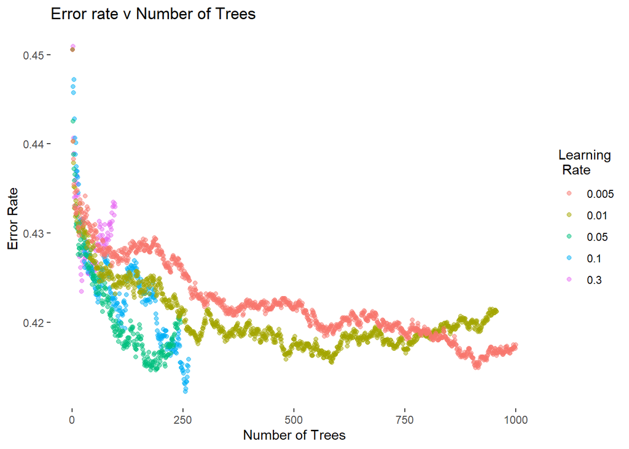

```r
# Extract results for model with eta = 0.3
pd1 <- cbind.data.frame(bst_mod_1$evaluation_log[,c("iter", "test_error_mean")], rep(0.3, nrow(bst_mod_1$evaluation_log)))
names(pd1)[3] <- "eta"
# Extract results for model with eta = 0.1
pd2 <- cbind.data.frame(bst_mod_2$evaluation_log[,c("iter", "test_error_mean")], rep(0.1, nrow(bst_mod_2$evaluation_log)))
names(pd2)[3] <- "eta"
# Extract results for model with eta = 0.05
pd3 <- cbind.data.frame(bst_mod_3$evaluation_log[,c("iter", "test_error_mean")], rep(0.05, nrow(bst_mod_3$evaluation_log)))
names(pd3)[3] <- "eta"
# Extract results for model with eta = 0.01
pd4 <- cbind.data.frame(bst_mod_4$evaluation_log[,c("iter", "test_error_mean")], rep(0.01, nrow(bst_mod_4$evaluation_log)))
names(pd4)[3] <- "eta"
# Extract results for model with eta = 0.005
pd5 <- cbind.data.frame(bst_mod_5$evaluation_log[,c("iter", "test_error_mean")], rep(0.005, nrow(bst_mod_5$evaluation_log)))
names(pd5)[3] <- "eta"
# Join datasets
plot_data <- rbind.data.frame(pd1, pd2, pd3, pd4, pd5)
# Converty ETA to factor
plot_data$eta <- as.factor(plot_data$eta)
# Plot points
g_6 <- ggplot(plot_data, aes(x = iter, y = test_error_mean, color = eta))+
  geom_point(alpha = 0.5) +
  theme_bw() + # Set theme
  theme(panel.grid.major = element_blank(), # Remove grid
        panel.grid.minor = element_blank(), # Remove grid
        panel.border = element_blank(), # Remove grid
        panel.background = element_blank()) + # Remove grid
  labs(x = "Number of Trees", title = "Error rate v Number of Trees",
       y = "Error Rate", color = "Learning \n Rate")  # Set labels
g_6
```

```r
set.seed(111111)
bst_final <- xgboost(data = dtrain, # Set training data



                     eta = .05, # Set learning rate
                     max.depth =  7, # Set max depth
                     min_child_weight = 3, # Set minimum number of samples in node to split
                     gamma = .2, # Set minimum loss reduction for split
                     subsample = .9, # Set proportion of training data to use in tree
                     colsample_bytree = .9, # Set number of variables to use in each tree

                     nrounds = 1000, # Set number of rounds
                     early_stopping_rounds = 50,
                     objective = "binary:logistic",
                     eval_metric = "error",
                     eval_metric = "auc",# Set number of rounds to stop at if there is no improvement

                     verbose = 1, # 1 - Prints out fit
                     nthread = 1, # Set number of parallel threads
                     print_every_n = 20 # Prints out result every 20th iteration

) # Set evaluation metric to use
```

```
## Multiple eval metrics are present. Will use train_auc for early stopping.
## Will train until train_auc hasn't improved in 50 rounds.
##
```

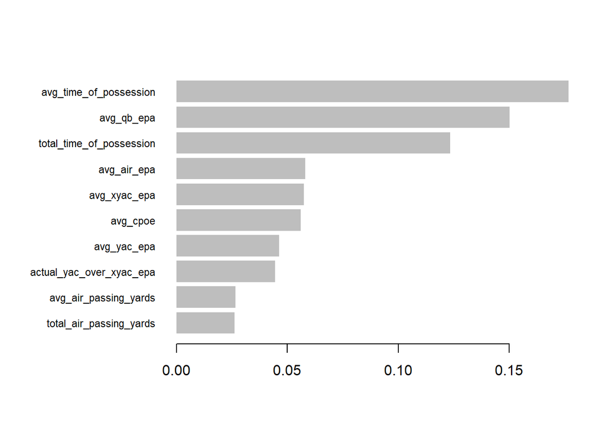

```r
# Extract importance
imp_mat <- xgb.importance(model = bst_final)
# Plot importance (top 10 variables)
xgb.plot.importance(imp_mat, top_n = 10)
```

The most important variables in order are average time of possession, average quarterback expected points added (epa), total time of possession, average air epa, average expected yards after catch epa, average completion percentage over expectatition, average yards after catch epa, actual yards after catch minus expected yards after catch epa, average air passing yards, and total air passing yards.

# Random Forest

```r
which(!nfl_train$win %in% c(0,1) )
```

```
##  [1]   65  133  194  251  329  389  457  531  593  662  790  914  992 1061 1125
## [16] 1185 1248 1315 1377 1552 1610 1677 1737 1808 1876 1949 2012 2138 2192 2384
## [31] 2638 2706 2774 2836 2901 2963 3030 3086 3152 3212 3285 3354 3412 3464 3596
## [46] 3667 3808 3876 3938 4017 4074 4141 4207 4258 4322 4386 4452 4516 4588 4713
## [61] 4784 4911 4979 5051 5126 5188 5247 5316 5451 5510 5577 5711 5782 5856 5902
## [76] 5977 6109 6188 6252 6328 6388 6460 6582 6647 6711 6850 6918 7052 7116 7182
## [91] 7250 7311
```

Here we assign a dataset called temp to the win values within the nfl_train dataset that aren’t 0 or 1

```r
temp <- nfl_train[which(!nfl_train$win %in% c(0,1) ),]
```

After, we create two new nfl_train and nfl_test datasets that only contain the values of 0 or 1

```r
nfl_train <- nfl_train[which(nfl_train$win %in% c(0,1)),]
nfl_test <- nfl_test[which(nfl_test$win %in% c(0,1)),]
```

```r
library(randomForest)
library(caret)

# Ensure that 'win' is a column in nfl_train
if (!("win" %in% colnames(nfl_train))) {
  stop("Column 'win' not found in nfl_train.")
}

# Set seed and fit random forest
set.seed(123456)
rf_mod_nfl <- randomForest(factor(win) ~ .,
                           data = nfl_train[,-c(2:5)],
                           ntree = 200,
                           nodesize = 1)

# Predict and evaluate
rf_pred_nfl <- predict(rf_mod_nfl, nfl_test, type = 'prob')
rf_pred_nfl <- as.factor(ifelse(rf_pred_nfl[,2] > 0.45, 1, 0))


rf_pred_nfl2 <- rep(0, length(rf_pred_nfl))


t <- table(rf_pred_nfl, nfl_test$win) # Create table
confusionMatrix(t, positive = "1")
```

```
## Confusion Matrix and Statistics
##
##
## rf_pred_nfl   0   1
##           0 376 268
##           1 555 653
##
##                Accuracy : 0.5556
##                  95% CI : (0.5326, 0.5784)
##     No Information Rate : 0.5027
##     P-Value [Acc > NIR] : 2.865e-06
##
##                   Kappa : 0.1127
##
##  Mcnemar's Test P-Value : < 2.2e-16
##
##             Sensitivity : 0.7090
##             Specificity : 0.4039
##          Pos Pred Value : 0.5406
##          Neg Pred Value : 0.5839
##              Prevalence : 0.4973
##          Detection Rate : 0.3526
##    Detection Prevalence : 0.6523
##       Balanced Accuracy : 0.5564
##
##        'Positive' Class : 1
##
```

In our first model, we see that the accuracy is 0.5556.

```r
tree_1 <- getTree(rf_mod_nfl, 1, labelVar=TRUE) # Extract single tree,
head(tree_1)
```

```
##   left daughter right daughter                split var  split point status
## 1             2              3                no_huddle   0.50000000      1
## 2             4              5 total_time_of_possession 234.50000000      1
## 3             6              7          first_down_rush   0.08129767      1
## 4             8              9    total_receiving_yards  48.50000000      1
## 5            10             11              avg_yac_epa  -0.86684195      1
## 6            12             13        total_first_downs   2.50000000      1
##   prediction
## 1       <NA>
## 2       <NA>
## 3       <NA>
## 4       <NA>
## 5       <NA>
## 6       <NA>
```

```r
oob_error <- rf_mod_nfl$err.rate[,1]
oob_error
```

[output not shown]

```r
length(oob_error)
```

```
## [1] 200
```

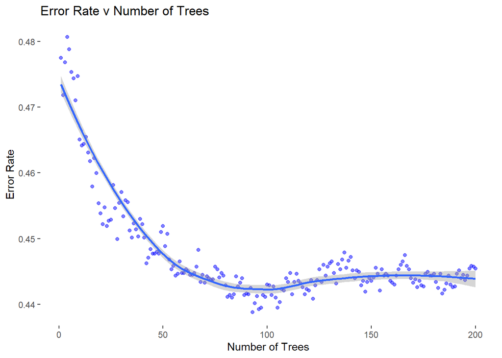

```r
plot_dat <- cbind.data.frame(rep(1:length(oob_error)), oob_error) # Create plot data
names(plot_dat) <- c("trees", "oob_error")


# Plot oob error
g_1 <- ggplot(plot_dat, aes(x = trees, y = oob_error)) + # Set x as trees and y as error
  geom_point(alpha = 0.5, color = "blue") + # Select geom point
  geom_smooth() + # Add smoothing line
  theme_bw() + # Set theme
  theme(panel.grid.major = element_blank(), # Remove grid
        panel.grid.minor = element_blank(), # Remove grid
        panel.border = element_blank(), # Remove grid
        panel.background = element_blank()) + # Remove grid
  labs(x = "Number of Trees", title = "Error Rate v Number of Trees",
       y = "Error Rate")  # Set labels
g_1 # Print plot
```

```r
set.seed(123456)
rf_mod_nfl2 <- randomForest(factor(win) ~ .,
                           data = nfl_train[,-c(2:5)],
                           ntree = 1000,
                           nodesize = 1)

# Predict and evaluate
rf_pred_nfl2 <- predict(rf_mod_nfl2, nfl_test, type = 'prob')
rf_pred_nfl2 <- as.factor(ifelse(rf_pred_nfl2[,2] > 0.45, 1, 0))


rf_pred_nfl3 <- rep(0, length(rf_pred_nfl2))


t <- table(rf_pred_nfl2, nfl_test$win) # Create table
confusionMatrix(t, positive = "1")
```

```
## Confusion Matrix and Statistics
##
##
## rf_pred_nfl2   0   1
##            0 385 263
##            1 546 658
##
##                Accuracy : 0.5632
##                  95% CI : (0.5402, 0.5859)
##     No Information Rate : 0.5027
##     P-Value [Acc > NIR] : 1.057e-07
##
##                   Kappa : 0.1278
##
##  Mcnemar's Test P-Value : < 2.2e-16
##
##             Sensitivity : 0.7144
##             Specificity : 0.4135
##          Pos Pred Value : 0.5465
##          Neg Pred Value : 0.5941
##              Prevalence : 0.4973
##          Detection Rate : 0.3553
##    Detection Prevalence : 0.6501
##       Balanced Accuracy : 0.5640
##
##        'Positive' Class : 1
##
```

ere we see that by using a larger number of trees we actually suffered a small increase in accuracy from 0.5556 to 0.5632.

```r
oob_error <- rf_mod_nfl2$err.rate[,1]
oob_error
```

[output not shown]

[output cut: 128 more lines]

```r
length(oob_error)
```

```
## [1] 1000
```

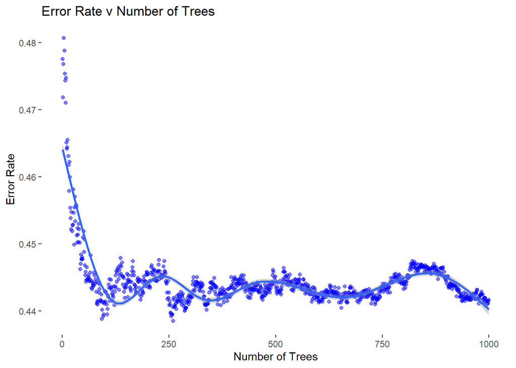

```r
plot_dat <- cbind.data.frame(rep(1:length(oob_error)), oob_error) # Create plot data
names(plot_dat) <- c("trees", "oob_error") # Name plot data


# Plot oob error
g_2 <- ggplot(plot_dat, aes(x = trees, y = oob_error)) + # Set x as trees and y as error
  geom_point(alpha = 0.5, color = "blue") + # Select geom point
  geom_smooth() + # Add smoothing line
  theme_bw() + # Set theme
  theme(panel.grid.major = element_blank(), # Remove grid
        panel.grid.minor = element_blank(), # Remove grid
        panel.border = element_blank(), # Remove grid
        panel.background = element_blank()) + # Remove grid
  labs(x = "Number of Trees", title = "Error Rate v Number of Trees",
       y = "Error Rate")  # Set labels
g_2 # Create plot
```

```r
plot_dat <- cbind.data.frame(rep(1:length(oob_error)), oob_error) # Create plot data
# Careful this can take a long time to run
trees <- c(10, 25, 50, 100, 200, 500, 1000) # Create vector of possible tree sizes
nodesize <- c(1, 10, 25, 50, 100, 200, 500, 1000) # Create vector of possible node sizes

params <- expand.grid(trees, nodesize) # Expand grid to get data frame of parameter combinations
names(params) <- c("trees", "nodesize") # Name parameter data frame
res_vec <- rep(NA, nrow(params)) # Create vector to store accuracy results

for(i in 1:nrow(params)){ # For each set of parameters
  set.seed(987654) # Set seed for reproducability
  mod <- randomForest(as.factor(win) ~.,
                      data = nfl_train[,-c(2:5)], # Set data
                      mtry = 7, # Set number of variables
                      importance = FALSE,  #
                      ntree = params$trees[i], # Set number of trees
                      nodesize = params$nodesize[i]) # Set node size
  res_vec[i] <- 1 - mod$err.rate[nrow(mod$err.rate),1] #Professor Martin the issue with length is here. I messed with this equation a little
}
```

```r
summary(res_vec)
```

```
##    Min. 1st Qu.  Median    Mean 3rd Qu.    Max.
##  0.5325  0.5524  0.5584  0.5553  0.5606  0.5633
```

```r
res_db <- cbind.data.frame(params, res_vec) # Join parameters and accuracy results
names(res_db)[3] <- "oob_accuracy" # Name accuracy results column
res_db # Print accuracy results column
```

```
##    trees nodesize oob_accuracy
## 1     10        1    0.5341497
## 2     25        1    0.5507834
## 3     50        1    0.5547002
## 4    100        1    0.5594273
## 5    200        1    0.5530794
## 6    500        1    0.5617234
## 7   1000        1    0.5621286
## 8     10       10    0.5429624
## 9     25       10    0.5415991
## 10    50       10    0.5484873
## 11   100       10    0.5574014
## 12   200       10    0.5632091
## 13   500       10    0.5582118
## 14  1000       10    0.5603728
```

[output cut: 42 more lines]

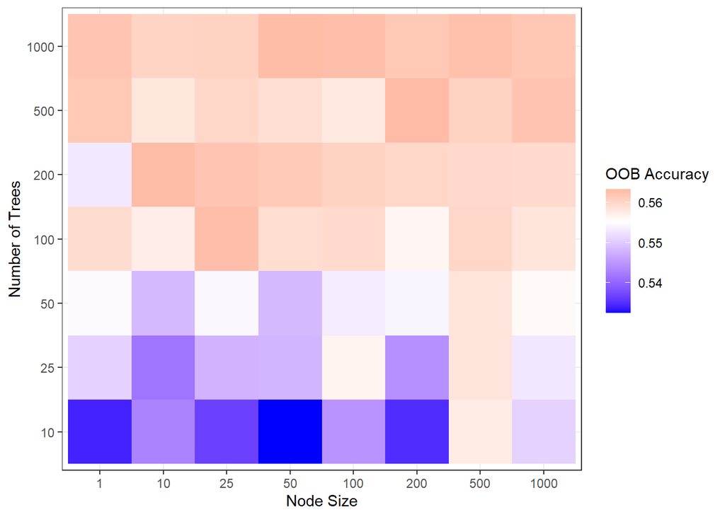

```r
res_db$trees <- as.factor(res_db$trees) # Convert tree number to factor for plotting
res_db$nodesize <- as.factor(res_db$nodesize) # Convert node size to factor for plotting
g_2 <- ggplot(res_db, aes(y = trees, x = nodesize, fill = oob_accuracy)) + # set aesthetics
  geom_tile() + # Use geom_tile for heatmap
  theme_bw() + # Set theme
  scale_fill_gradient2(low = "blue", # Choose low color
    mid = "white", # Choose mid color
    high = "red", # Choose high color
    midpoint =mean(res_db$oob_accuracy), # Choose mid point
    space = "Lab",
    na.value ="grey", # Choose NA value
    guide = "colourbar", # Set color bar
    aesthetics = "fill") + # Select aesthetics to apply
  labs(x = "Node Size", y = "Number of Trees", fill = "OOB Accuracy") # Set labels
g_2 # Generate plot
```

Here we see that a high number of trees and mix of high and low node size produce the best OOB accuracy. I decided to used 1000 trees and 1 node size due to the higher accuracy from before

```r
res_db[which.max(res_db$oob_accuracy),] # View best set of results
```

```
##    trees nodesize oob_accuracy
## 41   500      200    0.5633441
```

```r
set.seed(123456)
rf_mod_nfl3 <- randomForest(factor(win) ~., # Set tree formula
               data = nfl_train[,-c(2:5)], # Set dataset

                ntree = 1000, # Set number of trees
                nodesize = 1) # Set node size



# Predict and evaluate
rf_pred_nfl3 <- predict(rf_mod_nfl3, nfl_test, type = 'prob')
rf_pred_nfl3 <- as.factor(ifelse(rf_pred_nfl3[,2] > 0.45, 1, 0))


rf_pred_nfl4 <- rep(0, length(rf_pred_nfl3))


t <- table(rf_pred_nfl3, nfl_test$win) # Create table
confusionMatrix(t, positive = "1")
```

```
## Confusion Matrix and Statistics
##
##
## rf_pred_nfl3   0   1
##            0 385 263
##            1 546 658
##
##                Accuracy : 0.5632
##                  95% CI : (0.5402, 0.5859)
##     No Information Rate : 0.5027
##     P-Value [Acc > NIR] : 1.057e-07
##
##                   Kappa : 0.1278
##
##  Mcnemar's Test P-Value : < 2.2e-16
##
##             Sensitivity : 0.7144
##             Specificity : 0.4135
##          Pos Pred Value : 0.5465
##          Neg Pred Value : 0.5941
##              Prevalence : 0.4973
##          Detection Rate : 0.3553
##    Detection Prevalence : 0.6501
##       Balanced Accuracy : 0.5640
##
##        'Positive' Class : 1
##
```

The accuracy for the third model stayed at 0.5632

```r
rf_mod_nfl4 <- randomForest(factor(win) ~., # Set tree formula
               data = nfl_train[,-c(2:5)], # Set dataset

                ntree = 1000, # Set number of trees
                nodesize = 1,  # Set node size
                importance = TRUE, # Set to true to generate importance matrix
                proximity = TRUE) # Set to true to generate proximity matrix



# Predict and evaluate
rf_pred_nfl4 <- predict(rf_mod_nfl4, nfl_test, type = 'prob')
rf_pred_nfl4 <- as.factor(ifelse(rf_pred_nfl4[,2] > 0.45, 1, 0))


rf_pred_nfl5 <- rep(0, length(rf_pred_nfl4))


t <- table(rf_pred_nfl4, nfl_test$win) # Create table
confusionMatrix(t, positive = "1")
```

```
## Confusion Matrix and Statistics
##
##
## rf_pred_nfl4   0   1
##            0 384 273
##            1 547 648
##
##                Accuracy : 0.5572
##                  95% CI : (0.5343, 0.58)
##     No Information Rate : 0.5027
##     P-Value [Acc > NIR] : 1.463e-06
##
##                   Kappa : 0.1159
##
##  Mcnemar's Test P-Value : < 2.2e-16
##
##             Sensitivity : 0.7036
##             Specificity : 0.4125
##          Pos Pred Value : 0.5423
##          Neg Pred Value : 0.5845
##              Prevalence : 0.4973
##          Detection Rate : 0.3499
##    Detection Prevalence : 0.6452
##       Balanced Accuracy : 0.5580
##
##        'Positive' Class : 1
##
```

In our final model, we found that the accuracy decreased to 0.5572 from 0.5632.

```r
importance_matrix <- randomForest::importance(rf_mod_nfl4)
# Print importance matrix
importance_matrix
```

```
##                                      0          1 MeanDecreaseAccuracy
## total_passing_yards         -1.7014514  7.1013629             9.094865
## pass_attempts               -3.4669241  7.3465693             8.560903
## incomplete_pass              3.1090051  2.6996458             8.270547
## completion_per               0.4117208  5.3111294             8.816617
## avg_passing_yards           -1.2524493  7.9054311            10.899227
## total_air_passing_yards      4.6092422  2.1823778            12.390096
## avg_air_passing_yards        3.4055915  2.2836167             9.310320
## pass_touchdown              -0.5961569 11.7601735            13.247207
## total_rushing_yards          0.7210463  6.5087798            11.324839
## avg_rushing_yards            1.3231425  2.8167770             6.333670
## rush_attempt                 3.1259477  6.2033252            13.593047
## rush_touchdown               0.8157328 13.5024715            15.056059
## total_receiving_yards       -1.4430111  7.4579259            10.132931
## avg_receiving_yards          0.2323727  6.2056350            10.548037
## avg_cpoe                     9.6618293 -3.3665549             9.242490
## avg_qb_epa                  -9.7604328 26.2026835            21.347928
## avg_xyac_epa                 2.0442778  5.8108649            10.797748
## avg_time_of_possession       7.5389306 15.4702850            29.415048
## total_time_of_possession    -1.7900209 14.3029229            20.450322
## avg_air_epa                  3.1731574  4.2028175            10.064783
## avg_yac_epa                  2.8742596  3.0344441             9.281194
## actual_yac_over_xyac_epa    11.6055657 -3.9238338            11.446425
## total_actual_yac_over_xyac   2.3268049  4.8912692             9.301861
## avg_actual_yac_over_xyac    -0.6796695  6.4483037             7.584798
## total_penalty_yards         -8.3590420  8.4081007             1.231056
## total_first_downs          -13.2184193 17.2488935            12.507869
## interception                 3.9364876  3.3024983             7.211709
## fumble_lost                  6.0045916  1.3672785             8.115865
## fumble_forced                3.2010899  1.0858244             4.476446
## third_down_converted         3.3929990  2.1978159             5.314944
## third_down_failed            4.1668349  0.9469862             5.328297
## fourth_down_converted        2.6880101  1.9030576             4.898064
## fourth_down_failed          14.3881482  4.0534977            16.628797
## shotgun                      4.6184923  6.4337613            12.013264
## no_huddle                    2.3890963 17.3294204            13.970342
## qb_dropback                 -0.2317082  8.0274282            12.729684
## qb_scramble                  2.0298107 -5.7839583            -3.050277
## first_down_rush             -4.1205540  8.1965740             8.071816
## first_down_pass             -3.5089219  5.1029406             3.514697
```

[output cut: 25 more lines]

```
## total_penalty_yards               43.286970
## total_first_downs                 31.558496
## interception                       4.569265
## fumble_lost                        5.835014
## fumble_forced                      7.989225
## third_down_converted              23.047188
## third_down_failed                 36.700855
## fourth_down_converted              9.544305
## fourth_down_failed                12.092455
## shotgun                           78.373896
## no_huddle                         37.703956
## qb_dropback                       34.359003
## qb_scramble                       14.714639
## first_down_rush                   16.458659
## first_down_pass                   12.677414
```

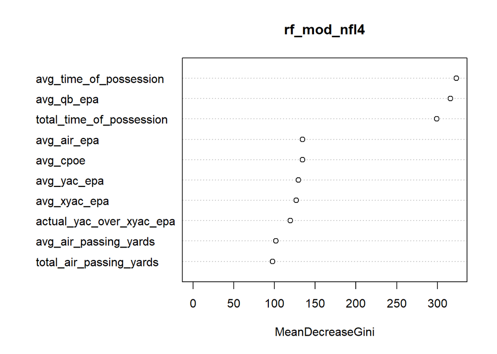

```r
varImpPlot(rf_mod_nfl4, type =2, n.var = 10) # Plot importance
```

The most important variables in order are average time of possession, average quarterback expected points added (epa), total time of possession, average air epa, average completion percentage over expectatition, average yards after catch epa, average expected yards after catch epa, actual yards after catch minus expected yards after catch epa, average air passing yards, and total air passing yards.

```r
rf_pred_nfl4 <- predict(rf_mod_nfl4, nfl_test, type = 'prob')
#rf_pred_nfl4 <- as.factor(ifelse(rf_pred_nfl4[,2] > 0.45, 1, 0))

# Assuming rf_pred_nfl4 contains your predicted values (0 or 1) and nfl_test$win contains the true labels
roc_obj <- roc(response = nfl_test$win, predictor = as.numeric(rf_pred_nfl4[,2]))
auc_value <- auc(roc_obj)

auc_value
```

```
## Area under the curve: 0.5876
```

Here we see that the AUC value is 0.5876

```r
dtrain <- xgb.DMatrix(data = as.matrix(nfl_train[,-c(1:5)]), label = as.numeric(nfl_train$win))
# Create test matrix



dtest <- xgb.DMatrix(data = as.matrix(nfl_test[,-c(1:5)]), label = as.numeric(nfl_test$win))
```

```r
xgb_preds <- predict(bst_final, dtest)
```

```r
roc_obj <- roc(response = nfl_test$win, predictor = xgb_preds)
auc_value <- auc(roc_obj)

auc_value
```

```
## Area under the curve: 0.6081
```

Here we see that the AUC value is 0.6081 which is better than our Random Forest model, so XGBoost is the best model.